# Critical Approach to Data Visualization

[figure not shown]

# Overview

This workshop led by UC Davis’ Data Feminism research and learning cluster unpacks the subjective process of data visualization and its relationship to concepts of diversity, equity and inclusion. We’ll critically explore how data can be used to uphold and perpetuate, or quantify and demonstrate structural oppression. Through this workshop learners will practice the technique of “data visceralization,” the process of experiencing differences in data and understanding them viscerally.

# Introduction

## Learning Objectives

After this workshop, participants should be able to:

- Critically read a dataset and its documentation
- Use the principles of data feminism to visualize data responsibly
- Consider visceralizing data in addition to visualizing them

## Before We begin

This workshop provides strategies for thinking critically about your data and help you visualize your data in more responsible and responsive ways. It will also help you consider how to present your data in meaningful ways that demonstrate impact and evoke emotion. This workshop will not provide technical instruction in data visualization. You can apply the frameworks described here to create data visualizations via any technology or medium.

This workshop will be interactive - you will work through case studies with your colleagues, brainstorm together, and share out what you have uncovered.

This workshop arose from efforts by the [UC Davis DataLab’s Data Feminism research and learning cluster](https://datalab.ucdavis.edu/data-feminism/), established by Drs. Merchant, Poirier and Reynolds in fall of 2019 with support from the [Feminist Research Institute](https://fri.ucdavis.edu/).

*You are welcome to use this workshop “reader” and the materials herein for your own instruction, provided that appropriate attribution is given.*

# Critical Approaches to Data Visualization

## Step 1: Read Your Data Carefully

To build a responsible data visualization of a variable in a dataset, you should first critically explore the data. The following types of readings of your data provide a helpful framework:

- **Denotative reading** - What is the technical definition underlying this statistic? You can often find this information in the data dictionaries and metadata (when available).
- **Connotative reading** - What is the cultural history of this definition? What controversies are there? How has this definition changed over time? Data collection documentation and grey literature can help you dig into this.
- **Deconstructive reading** - What is included by this definition? Perform critical analyses of the definitions, categories and structures to begin to understand who and what is being left out.

To illustrate this process, let’s look at a published visualization of population by sex from the U.S. Census:

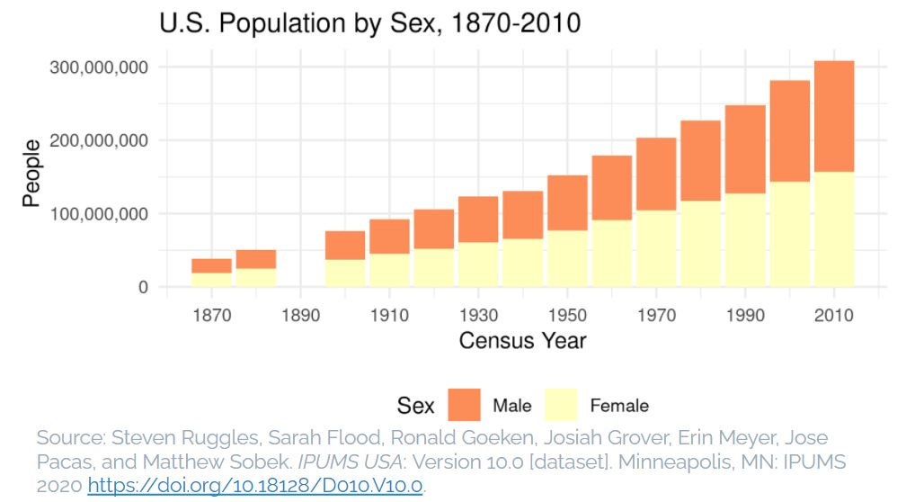

## Step 2: Visualizing Data Responsibly

Using what you learned above, you can now start to think about creating a more responsible data visualization. To do so, think about how you could:

- **Bring back the bodies** - be clear on who is included, and who is excluded.
- **Show your work and give credit where due** - cite your sources, methods, etc.
- **Acknowledge your standpoint** - it is impossible to create perfectly objective visualizations.
- **Use appropriate text** - titles, labels, captions, etc. can help readers better understand the complexities, and caveats, of the data.

Using those principles, we can improve the visualization:

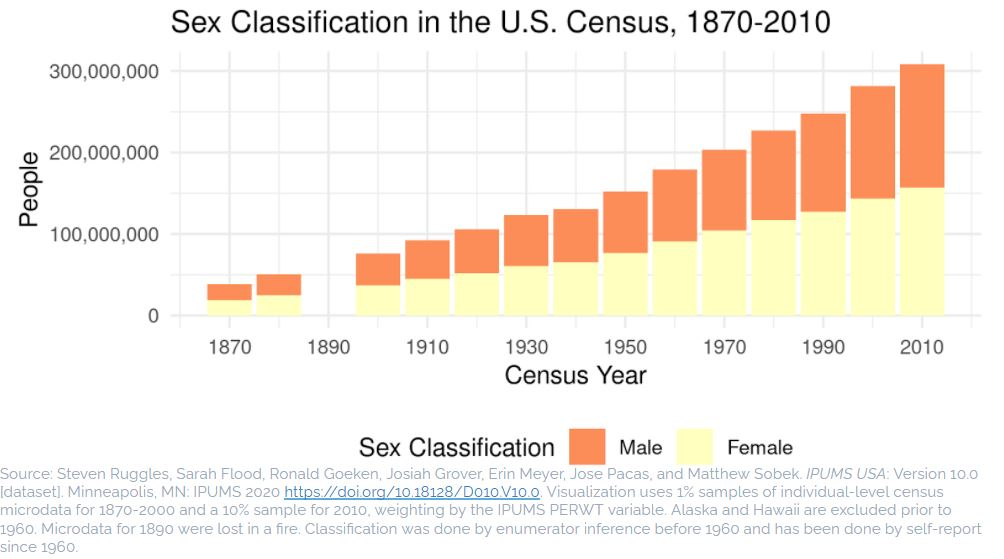

## Step 3: Visceralize Your Data

*“One death is a tragedy, a million deaths a statistic”* (attributed to Stalin, 1947). Now that you can create more responsible data visualizations, how can you demonstrate the importance of a message it conveys? One way to do that is visceralize your data to evoke emotion.

These are two examples of data visceralizations. How do these compare to a statistic? How do they make you feel?

- [US Gun Deaths](https://guns.periscopic.com/?year=2013)
- [COVID deaths](https://www.nytimes.com/interactive/2020/05/24/us/us-coronavirus-deaths-100000.html)

# Case Studies

This workshop will involve some group work in breakout rooms. In our first breakout session, you will be able to choose the group you want to join. If possible, please join one that has no more than seven other members (eight people total). Make a note of the group number so that you can return to the same group for subsequent breakout sessions. Please work with the dataset assigned to your group:

## Groups 1 and 2: Covid-19 deaths

- [History and provenance](https://www.scientificamerican.com/article/how-covid-19-deaths-are-counted1/)
- **Data:** [New York Times](https://github.com/nytimes/covid-19-data); [Johns Hopkins University](https://github.com/CSSEGISandData/COVID-19)
- [What counts?](https://theconversation.com/died-from-or-died-with-covid-19-we-need-a-transparent-approach-to-counting-coronavirus-deaths-145438)
- **Controversy:** [Why we don’t know the true death rate](https://www.nytimes.com/2020/04/17/us/coronavirus-death-rate.html); [Trump suggests virus death count is inflated](https://www.nytimes.com/2020/05/22/us/politics/coronavirus-trump-death-toll.html)

[Jamboard for Breakout Sessions](https://jamboard.google.com/d/1h2mnf2ZWB2xgShCNRMWAuOXLeI7exSAmmpqtH2kUgbM/edit?usp=sharing)

## Groups 3 and 4: Hurricane Maria death toll

- [History and provenance](https://simplystatistics.org/2018/09/28/the-complex-process-of-obtaining-puerto-rico-mortality-data-a-timeline/)
- **Data:** [U.S. Government](https://twitter.com/DavidBegnaud/status/1002658303904829442); [Harvard Chan School of Public Health](https://github.com/c2-d2/pr_mort_official); [Hurricane Maria Deaths Database](https://hurricanemariasdead.com/)
- [What counts?](https://apnews.com/article/910d274805054e3fa8ebf07a550c3920)
- [Controversy](https://www.nytimes.com/2018/06/02/us/puerto-rico-death-tolls.html)
- [Further reading](https://www.nature.com/articles/d41586-019-00442-0)

[Jamboard for Breakout Sessions](https://jamboard.google.com/d/10DkGnmQrgbNCt-8SyVGQsHFAsHImzBPUO83Qm7cXtHc/edit?usp=sharing)

## Groups 5 and 6: Drone warfare civilian casualties

- [History and provenance](https://www.lawfareblog.com/civilian-casualties-collateral-damage)
- [Data](https://www.thebureauinvestigates.com/projects/drone-war)
- [What counts?](https://web.law.columbia.edu/sites/default/files/microsites/human-rights-institute/COLUMBIACounting%20Drone%20Strike%20DeathsSUMMARY.pdf)
- [Controversy](https://www.nytimes.com/2019/03/30/opinion/drones-civilian-casulaties-trump-obama.html)
- [Further reading](https://www.cmu.edu/chrs/statistics_program/conflict-death-events/counting-civilian-casualties.html)

[Jamboard for Breakout Sessions](https://jamboard.google.com/d/1DBIqbdk-Walc99K0fGrKoh03jtvlcWvUkZkb5eTi9Sk/edit?usp=sharing)

## Groups 7 and 8: Maternal mortality

- [History and provenance](https://www.propublica.org/article/how-many-american-women-die-from-causes-related-to-pregnancy-or-childbirth)
- [Data](https://data.unicef.org/resources/data_explorer/unicef_f/?ag=UNICEF&df=GLOBAL_DATAFLOW&ver=1.0&dq=.MNCH_MMR+MNCH_LTR_MATERNAL_DEATH+MNCH_MATERNAL_DEATHS..&startPeriod=2016&endPeriod=)
- [What counts?](https://journalofethics.ama-assn.org/article/who-counts-what-counts-place-and-limits-perinatal-mortality-measures/2018-03)
- Controversy
- [Further reading](https://www.cdc.gov/nchs/data/series/sr_03/sr03_044-508.pdf)

[Jamboard for Breakout Sessions](https://jamboard.google.com/d/1jBIbvCSbJ4liP_g8nOu_2Nqb2PP8NuFL1hMOozF1T58/edit?usp=sharing)

## Groups 9 and 10: Police shootings

- [History and provenance](https://time.com/5861953/police-reform-use-of-force-database/)
- **Data:** [Washington Post](https://www.washingtonpost.com/graphics/investigations/police-shootings-database/); [Mapping Police Violence](https://mappingpoliceviolence.org/)
- [What counts?](https://www.motherjones.com/anti-racism-police-protest/2020/06/we-still-dont-really-know-how-many-americans-are-killed-or-injured-by-police/)
- [Controversy](https://www.brookings.edu/blog/how-we-rise/2020/06/26/theres-truth-in-numbers-in-policing-until-there-isnt/)

[Jamboard for Breakout Sessions](https://jamboard.google.com/d/1DSTFMyHvse9AdcRUtXOTc4G8Jqyu9NZXWy8_Gl7G5zM/edit?usp=sharing)

## Groups 11 and 12: Medical error deaths

- **History and provenance:** [Johns Hopkins University](https://www.hopkinsmedicine.org/news/media/releases/study_suggests_medical_errors_now_third_leading_cause_of_death_in_the_us); [British Medical Journal](http://www.tirf-labs.com/med%20error%20bmj.i2139.full.pdf)
- [Data](https://oig.hhs.gov/oei/reports/oei-06-09-00090.pdf)
- [What counts?](https://www.ncbi.nlm.nih.gov/pmc/articles/PMC3211566/)
- [Controversy](https://www.propublica.org/article/study-urges-cdc-to-revise-count-of-deaths-from-medical-error)

[Jamboard for Breakout Sessions](https://jamboard.google.com/d/10AJN8dGj_jtOncinakaF7zOj6wpKiXzbGvZO9xrT474/edit?usp=sharing)

# Exercises

## Step one: Read data critically

In this section, you will learn the difference between denotative, connotatative, and deconstructive readings of a dataset; how to do each; and why all three are necessary in order to analyze and visualize your data accurately and responsibly.

**In your breakout room:** Using the links provided above, explore the dataset assigned to your group. Choose *one* variable to read denotatively, connotatively, and deconstructively. Select one person to report on these readings to the workshop as a whole.

## Step two: Visualize your data responsibly

In this section, you will learn how to apply your denotative, connotative, and deconstructive readings to standard data visualizations. We will go over some of the principles of feminist data visualization — such as acknowledging your standpoint, showing your work, and giving credit where due — and discuss how to use them in practice.

**In your breakout room:** How would you visualize the variable you analyzed in the previous step? How would you incorporate the principles of feminist data visualization? What kind of argument would your visualization make? Choose one person to report back to the workshop.

## Step three: Visceralize your data

In this section, we will discuss strategies for going beyond standard data visualizations to consider ways of presenting data that might evoke the appropriate emotions in your audience.

**In your breakout room:** If you were not constrained by standard data visualization software (or your own artistic abilities), how would you visceralize the variable you have been working with? Choose one person to report back to the workshop.

# Resources

Check out our curated [Data Feminism reading list](https://www.zotero.org/groups/2324756/data_feminism/items).

D’lgnazio, C., and Klein, L. 2020. [Data Feminism](https://data-feminism.mitpress.mit.edu/). Cambridge, Massachusetts: The MIT Press.

Cifor, M., Garcia, P., Cowan, T.L., Rault, J., Sutherland, T., Chan, A., Rhode, J., Hoffmann, A.L., Salehi, N., Nakamura, L. 2019. Feminist Data Manifest-No. Retrieved from: https://www.manifestno.com/.

UC Davis affiliates are welcome to join [DataLab’s Data Feminism research and learning cluster](https://datalab.ucdavis.edu/data-feminism/).